# Molusco 3

Gabriel de Jesus Pereira

2024-06-06

## Carregando banco de dados

```r
data <- read_csv("../abalone.csv") |>
  mutate(
    Sex = ifelse(Sex == "M" | Sex == "F", "A", Sex) |>
      as.factor()
    ) |>
  dplyr::select(-c(Rings, Height))

splits <- initial_split(data)
train <- training(splits)
test <- testing(splits)
```

## Sobre o banco de dados

- É um banco de dados da área de biologia que contém medidas físicas de um abalone;
- O banco de dados contém 4177 observações;
- 7 colunas, sendo uma delas nominal e o restante numérica;
- Foi criado por Warwick Nash, Tracy Sellers, Simon Talbot, Andrew Cawthorn, Wes Ford.

## As variáveis do banco de dados

- Sexo do abalone: variável nominal indicando se o abalone é macho ou filhote. No entanto o macho e a fêmea foi juntado numa única classe de adultos para fazer a comparação.
- Medição do maior comprimento da concha
- Diâmetro: perpendicular ao comprimento
- Peso inteiro do abalone

## As variáveis do banco de dados

- Peso da carne do abalone
- Peso das vísceras
- Peso da concha sem carne

# Análise de correlação canônica

## Seleção do conjunto de variáveis

O conjunto de variáveis independentes escolhida foi a *medição do maior comprimento da concha*, *diamêtro* e o *peso total*. Já o conjunto de variáveis dependentes é composto pelo, *peso da carne*, *peso das vísceras* e *peso da concha sem carne*. Além disso, os machos e as fêmeas foram juntados numa única classe de adultos.

## Correlação entre o conjunto de variáveis

- Código
- Correlação

```r
X <- data |>
  dplyr::select(Length, Diameter, `Whole weight`)
Y <- data |>
  dplyr::select(-c(Length, Diameter, Sex, `Whole weight`))

correl <- matcor(X, Y)
```

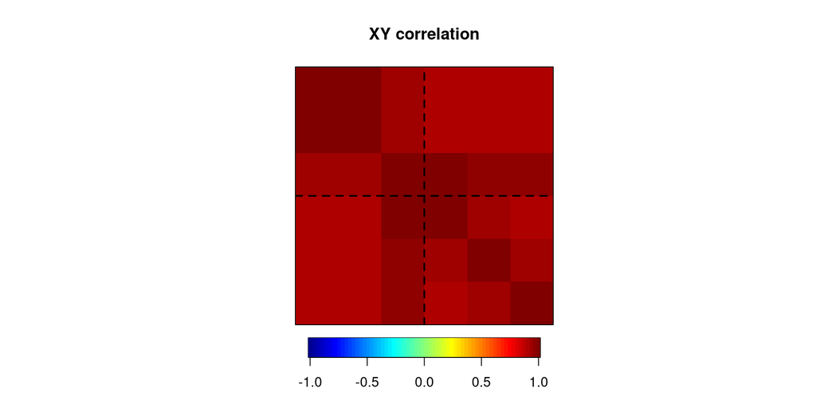

## Correlação entre o conjunto de variáveis

A partir do gráfico anterior, podemos ver que o conjunto de variáveis independentes e dependentes são bastante correlacionados.

## Correlação canônica

- Código
- Correlação canônica

```r
cca.fit <- cca(X, Y)

barplot(
  cca.fit$corr,
  xlab = "Dimensão",
  ylab = "Correlação canônica",
  names.arg = 1:3,
  ylim = c(0, 1),
  col = "#21908C"
  )
```

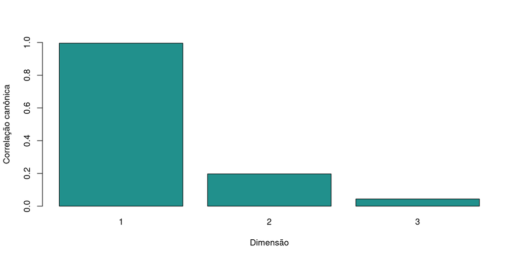

## Correlação canônica

Pelo gráfico de barras, podemos ver que as variáveis canônicas de $\left(U1, V1\right)$ são bastante correlacionadas, chegando a 99.56%. Já para $\left(U2, V2\right)$ a correlação foi apenas de 19.71%, bastante baixa.

## Testes para significância do par canônico

```r
res.cc <- cc(X, Y)
rho <- res.cc$cor
nn <- dim(X)[1]; pp <- dim(X)[2]; qq <- dim(Y)[2]
p.asym(rho, N=nn, p=pp, q=qq, tstat = "Hotelling")
```

```
 Hotelling-Lawley Trace, using F-approximation:
                 stat       approx df1   df2     p.value
1 to 3:  1.134889e+02 52578.967246   9 12509 0.000000000
2 to 3:  4.237655e-02    44.195209   4 12515 0.000000000
3 to 3:  1.927222e-03     8.043584   1 12521 0.004573836
```

```r
p.asym(rho, N=nn, p=pp, q=qq, tstat = "Wilks")
```

```
Wilks' Lambda, using F-approximation (Rao's F):
                stat      approx df1      df2     p.value
1 to 3:  0.008381861 6917.671520   9 10151.27 0.000000000
2 to 3:  0.959274478   43.819795   4  8344.00 0.000000000
3 to 3:  0.998076485    8.042299   1  4173.00 0.004591757
```

```r
p.asym(rho, N=nn, p=pp, q=qq, tstat = "Pillai")
```

```
 Pillai-Bartlett Trace, using F-approximation:
                stat     approx df1   df2     p.value
1 to 3:  1.032062593 729.494273   9 12519 0.000000000
2 to 3:  0.040800302  43.172465   4 12525 0.000000000
3 to 3:  0.001923515   8.039678   1 12531 0.004583696
```

## Testes para significância do par canônico

Foram realizados 3 testes para verificar a significância do par canônico: Pillai-Bartlett, Wilks’ Lambda e Hotelling-Lawley. Pelos testes, foi possível verificas que todos os conjuntos de pares canônicos são significativos.

## Variância total explicada pela variável canônica $U_k$

- Código
- $U_k$

```r
loadings <- comput(X,Y, res.cc)
pvte.u <- (colSums((loadings$corr.X.xscores)^2))/(dim(X)[2])*100
barplot(
  pvte.u,
  xlab = "Variável",
  ylab = "Variância total explicada",
  names.arg = 1:3,
  ylim = c(0, 1),
  col = "#21908C"
)
```

[figure not shown]

## Variância total explicada pela variável canônica $U_k$

Podemos ver que a variável canônica $U_1$ explica 91.3094% da variância original do grupo de variáveis independentes, enquanto a segunda explica apenas 2.4725%.

## Variância total explicada pela variável canônica $V_k$

- Código
- $V_k$

```r
pvte.v <- (colSums((loadings$corr.Y.yscores)^2))/(dim(Y)[2])*100
barplot(
  pvte.v / sum(pvte.v),
  xlab = "Variável",
  ylab = "Variância total explicada",
  names.arg = 1:3,
  ylim = c(0, 1),
  col = "#21908C"
)
```

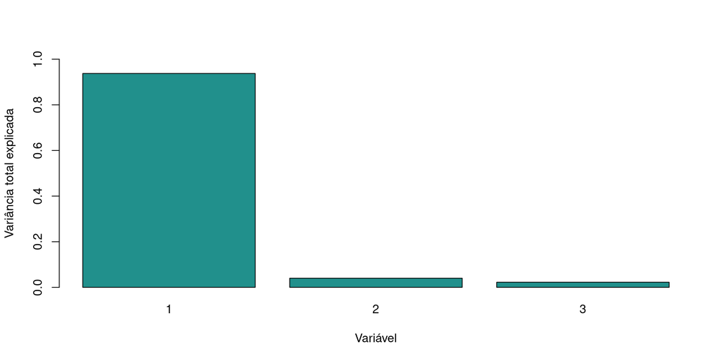

## $R^2$ canônico

Indica o quanto da variância da variável canônica dependente é explicada pela variável canônica.

```r
res.cc$cor ^ 2
```

```
[1] 0.991262291 0.038876787 0.001923515
```

Dessa forma, 99.12% da primeira variável canônica dependente é explicada pela primeira variável canônica independente. De forma semelhante, 3.88% e 0.1923% da segunda e terceira variável canônica dependente é explicada pela segunta e terceira variável canônica independente, respectivamente.

## Índice de redundância

```r
ir.x <- (colSums((loadings$corr.X.xscores)^2))/(dim(X)[2])*(res.cc$cor^2)
ir.y <- (colSums((loadings$corr.Y.yscores)^2))/(dim(Y)[2])*(res.cc$cor^2)
ir.x
```

```
[1] 0.9051161006 0.0009612661 0.0001196034
```

```r
ir.y
```

```
[1] 9.292072e-01 1.562568e-03 4.310457e-05
```

Pelo índice de redundância, podemos que o segundo e terceiro pares canônicos, apesar dos testes estatísticos tendo mostrado que os pares canônicos são significativos, tem pouco ou nenhum significado prático. Dessa forma, a análise poderia ser feita considerando apenas o primeiro par canônico.

## Gráficos

No último plot, podemos ver o quanto o cada par foi mais importante para explicar a variância. Ainda, podemos ver que como as variáveis e o conjunto de variáveis são extremamente correlacionados, todas contribuem bastante para explicar a variância para os pares.

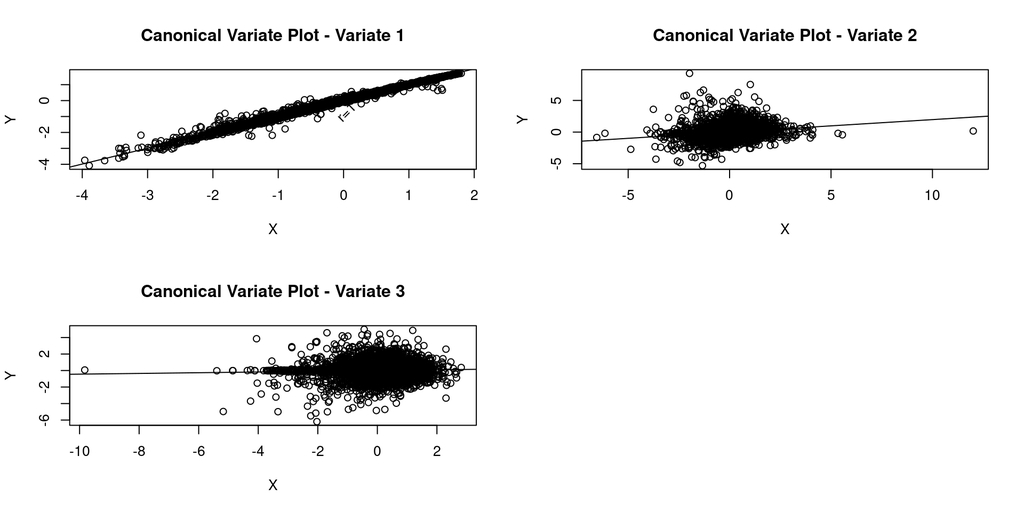

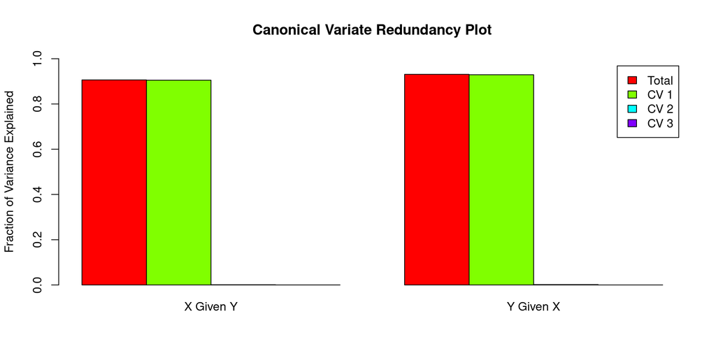

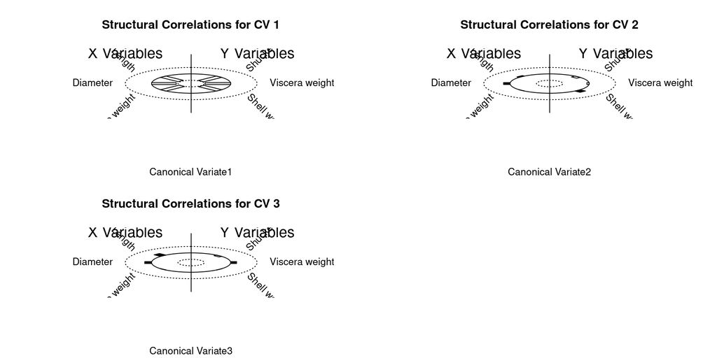

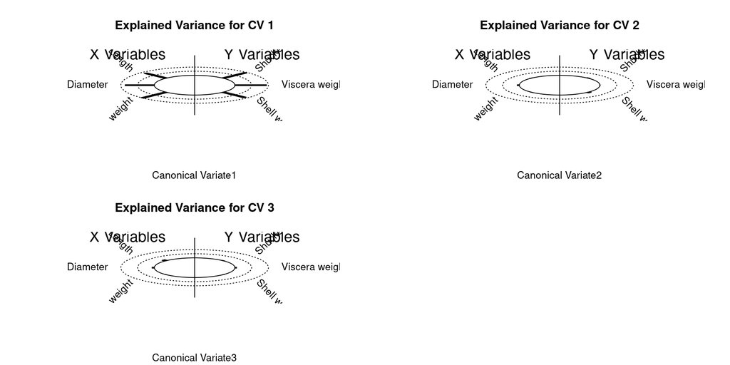

```r
plot.cca(cca.fit)
```

# Análise de discriminante

## Linear

```r
colnames(train) <- make.names(colnames(train))
colnames(test) <- make.names(colnames(test))
linear <- lda(Sex ~ ., test)

pred_l <- predict(linear, test)
cm1 <- confusionMatrix(test$Sex, pred_l$class)
cm1$table
```

```
          Reference
Prediction   A   I
         A 629  77
         I 117 222
```

## Resultados do caso linear

84.32% dos casos em que o molusco é adulto foi corretamente classificado e 74.25% dos casos em que o molusco é filhote foi corretamente identificado. Além disso, o modelo tem uma acurácia obteve uma acurácia de 81.44%, que é a proporção de predições corretas.

## Curva ROC

```r
roc_obj_l <- roc(test$Sex, pred_l$posterior[, 1])
auc(roc_obj_l)
```

```
Area under the curve: 0.8797
```

```r
plot(roc_obj_l)
```

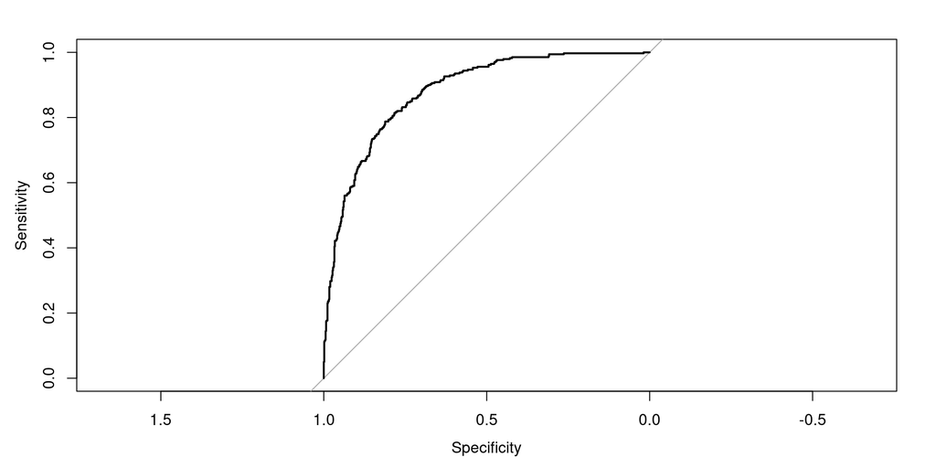

## Discriminação

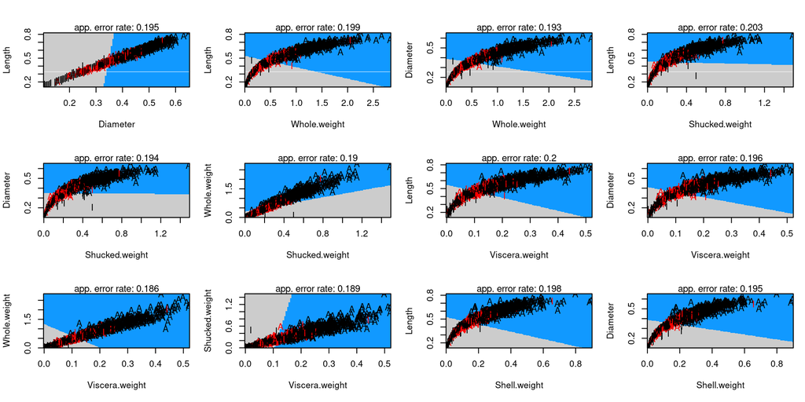

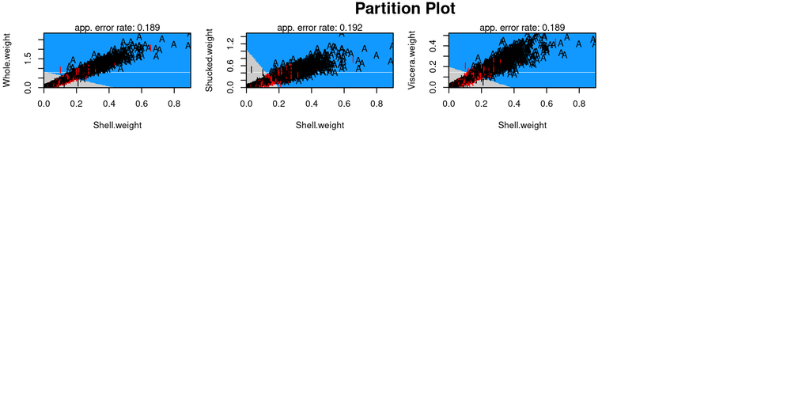

```r
partimat(Sex ~ ., data = test, method = "lda",
         image.colors = c("#1199ff", "#cccccc")
         )
```

## Quadrático

```r
quadratico <- qda(Sex ~ ., train)

pred_q <- predict(quadratico, test)
cm2 <- confusionMatrix(test$Sex, pred_q$class)
cm2$table
```

```
          Reference
Prediction   A   I
         A 528 178
         I  56 283
```

## Resultados do caso quadrático

Para o caso quadrático a classificação dos moluscos machos ficou um pouco melhor, alcançando 90.41% dos casos em que o molusco é adulto foi corretamente classificado e 61.39% dos casos em que o molusco é filhote foi corretamente identificado. Além disso, o modelo tem uma acurácia obteve uma acurácia de 77.61%, que é a proporção de predições corretas. No entanto, perceba que a acurácia é menor e a classificação para os filhotes fica pior que no caso linear.

## Curva ROC

```r
roc_obj_q <- roc(test$Sex, pred_q$posterior[, 1])
auc(roc_obj_q)
```

```
Area under the curve: 0.8666
```

```r
plot(roc_obj_q)
```

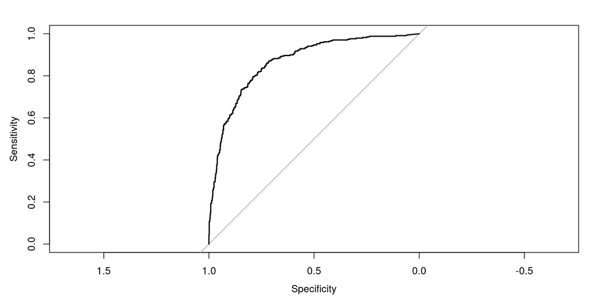

## Discriminação

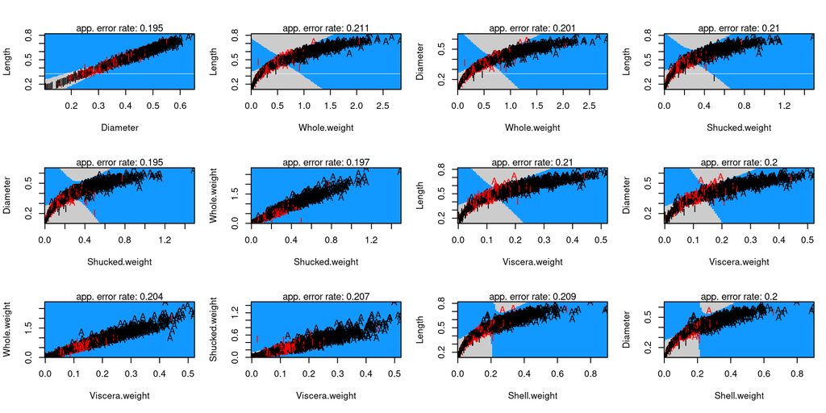

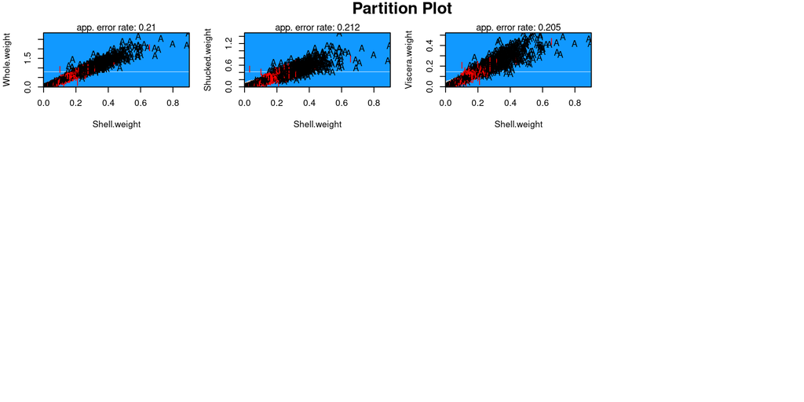

```r
partimat(Sex ~ ., data = test, method = "qda",
         image.colors = c("#1199ff", "#cccccc")
         )
```